# Diamonds!

Ми починаємо, як завжди, з необхідних бібліотек

```r
#install.packages('GGally')
#install.packages('ggplot2')
#install.packages('scales')
#install.packages('memisc')

library(tidyverse)
library(ggplot2)
library(GGally)
library(scales)
data(diamonds)
```

Подивимося на дані:

```r
diamonds %>% tbl_df()
```

```
## # A tibble: 53,940 x 10
##    carat       cut color clarity depth table price     x     y     z
##    <dbl>     <ord> <ord>   <ord> <dbl> <dbl> <int> <dbl> <dbl> <dbl>
##  1  0.23     Ideal     E     SI2  61.5    55   326  3.95  3.98  2.43
##  2  0.21   Premium     E     SI1  59.8    61   326  3.89  3.84  2.31
##  3  0.23      Good     E     VS1  56.9    65   327  4.05  4.07  2.31
##  4  0.29   Premium     I     VS2  62.4    58   334  4.20  4.23  2.63
##  5  0.31      Good     J     SI2  63.3    58   335  4.34  4.35  2.75
##  6  0.24 Very Good     J    VVS2  62.8    57   336  3.94  3.96  2.48
##  7  0.24 Very Good     I    VVS1  62.3    57   336  3.95  3.98  2.47
##  8  0.26 Very Good     H     SI1  61.9    55   337  4.07  4.11  2.53
##  9  0.22      Fair     E     VS2  65.1    61   337  3.87  3.78  2.49
## 10  0.23 Very Good     H     VS1  59.4    61   338  4.00  4.05  2.39
## # ... with 53,930 more rows
```

Зробим вибірку, для того щоб збільшити швидкість

```r
df <- diamonds %>%
  sample_n(5000) %>%
  tbl_df()
```

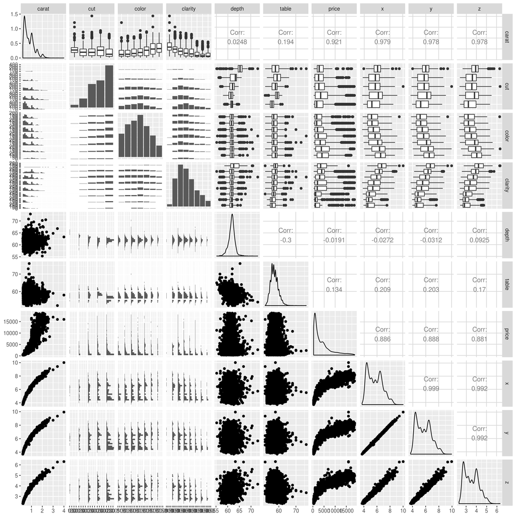

```r
df %>% ggpairs( )
```

Вище - дуже цікавий графік, варто його більш детально розгледіти. Нас цікавить ціна, тому дивимося на відповідну колонку. Є кореляція з color, clarity. Але головним чином ціна залежить від carat, x, y, z (нелінійно)

Отже, залишимо лише ці змінні

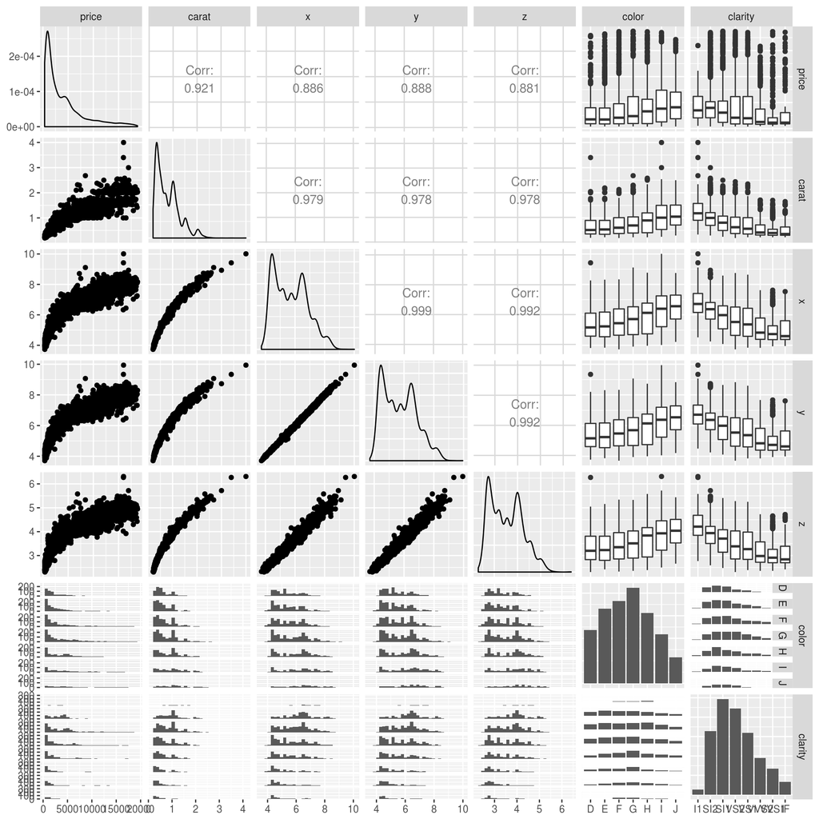

```r
df %>%
  select(price, carat, x, y, z, color, clarity) %>%
  ggpairs()
```

На що звернути увагу (купа можливих історій)

- Піки на розподілі каратності
- колір та чистота(clarity) корелюють з каратністю (вагою у каратах)?
- на діамантах більшого розміру розкид ціни збільшується - скоріш за все, попит низький і пропозиції не конкурують між собою

Часто, як в нашому випадку, монетарна змінна розкидана на декілька порядків величин та сильно викривлена в сторону менших цін. Це може бути викликано декількома механізмами:

- “залежність від шляху” (а.к.а. “багатші стають багатшими”)
- мультиплікацінйими процесами (інфляція протягом багатьох років)

(до речі, звідси походження power laws / логнормального розподілу) Сильно зсунутий розподіл цін проситься на логарифмічну шкалу: Спочатку, стандартна гістограма:

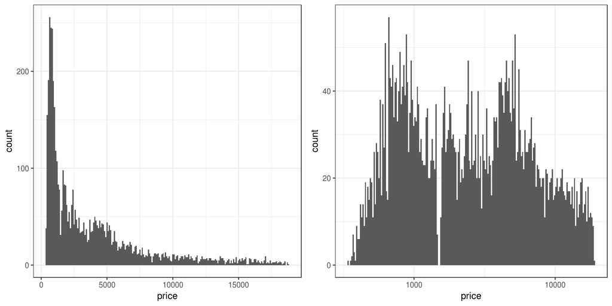

```r
library(gridExtra)
p1 <-
  df %>%
  ggplot(aes(x=price)) +
  geom_histogram(bins=200) +
  theme_bw()


p2 <-
  df %>%
  ggplot(aes(x=price)) +
  scale_x_log10() +
  geom_histogram(bins=200) +
  theme_bw()

grid.arrange(p1, p2, ncol = 2, nrow = 1)
```

Карат пропорційний x * y * z, що буде якщо взяти корінь кубічний з карату?

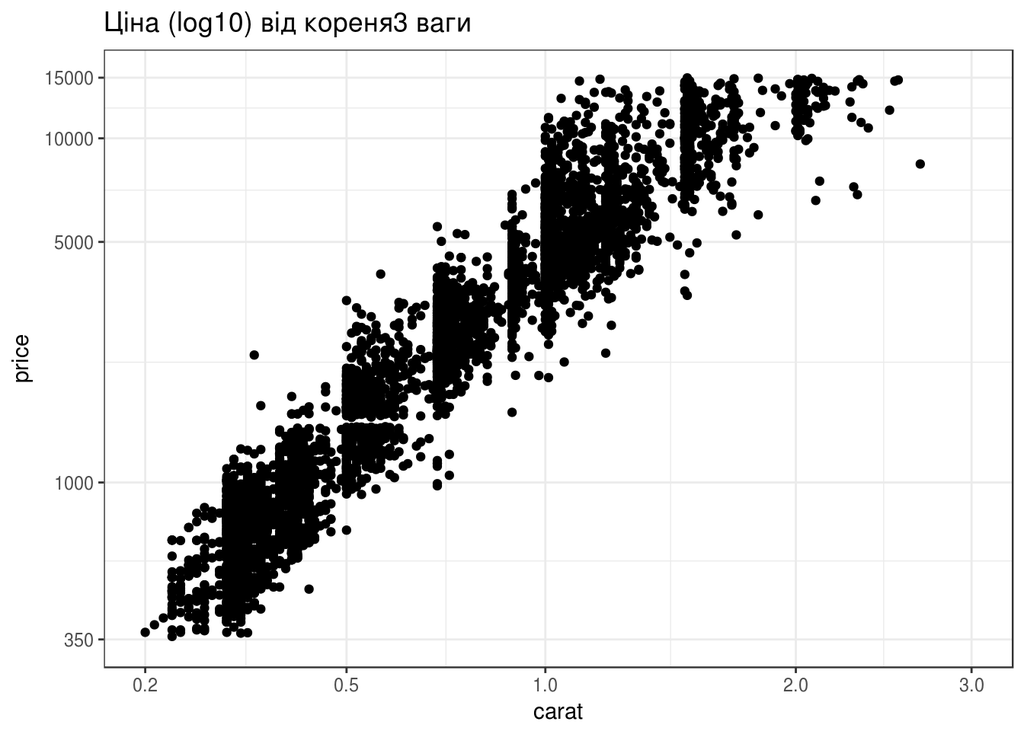

```r
cubroot_trans = function() trans_new('cubroot', transform= function(x) x^(1/3), inverse = function(x) x^3 )

p <- df %>%
    ggplot( aes(x=carat, y=price) ) +
    scale_x_continuous(trans=cubroot_trans(), limits = c(0.2,3),
        breaks = c(0.2, 0.5, 1, 2, 3)) +
    scale_y_continuous(trans=log10_trans(), limits = c(350,15000),
        breaks = c(350, 1000, 5000, 10000, 15000)) +
    geom_point() +
    theme_bw() +
    ggtitle('Ціна (log10) від кореня3 ваги')

p
```

Чудово! Після трансформації по Х та У ми отримали майже лінійну залежність! Бачите розриви на “красивих”, “круглих” значеннях каратності?

Щоб побороти занадто велику густину точок на графіку, давайте зменшимо їх прозорість та розмір - параметри alpha та size для функції geom_point()

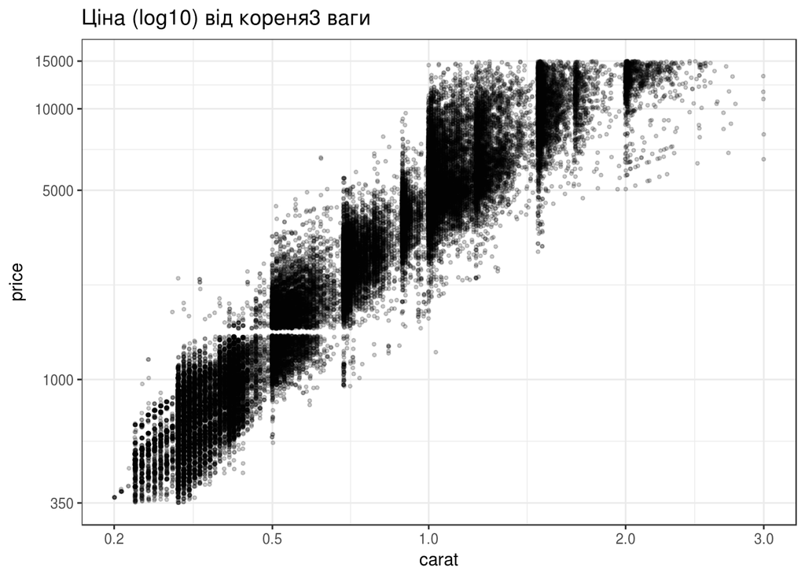

```r
p = ggplot( data=diamonds, aes(carat, price)) +
    geom_point(alpha = 0.2, size = .75, position='jitter') +
    scale_x_continuous(trans=cubroot_trans(), limits = c(0.2,3),
        breaks = c(0.2, 0.5, 1, 2, 3)) +
    scale_y_continuous(trans=log10_trans(), limits = c(350,15000),
        breaks = c(350, 1000, 5000, 10000, 15000)) +
    theme_bw() +
    ggtitle('Ціна (log10) від кореня3 ваги')
p
```

Додамо колір на графік, щоб побачити як залежить ціна ще й від чистоти

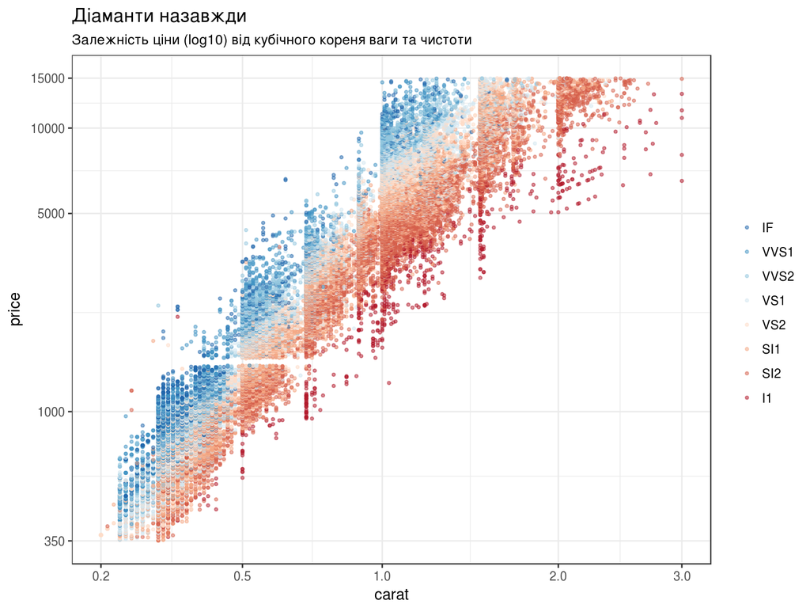

```r
p <- diamonds %>%
    ggplot(  aes(carat, price, colour=clarity)) +
    geom_point(alpha = 0.5, size = .75) +
    scale_colour_brewer(type = 'div', palette = 5,
        guide = guide_legend(title = NULL, reverse=T)) +
    scale_x_continuous(trans=cubroot_trans(), limits = c(0.2,3),
        breaks = c(0.2, 0.5, 1, 2, 3)) +
    scale_y_continuous(trans=log10_trans(), limits = c(350,15000),
        breaks = c(350, 1000, 5000, 10000, 15000)) +
    theme_bw() + theme(legend.key = element_blank()) +
    labs(title = "Діаманти назавжди", subtitle = 'Залежність ціни (log10) від кубічного кореня ваги та чистоти')
  #ggtitle('Price (log10) by Cubed-Root of Carat and Color')
p
```

Видно, що ціна в кожній вертикальній групі точок чітко розкладається по кольорам від синього до червоного в залежності від чистоти. Тобто, чистота - хоч і не настільки сильно впливає на ціну як розмір, але також впливає

Наостанок, можна подивитися як ціна залежить від кольору каменів (змінна color)

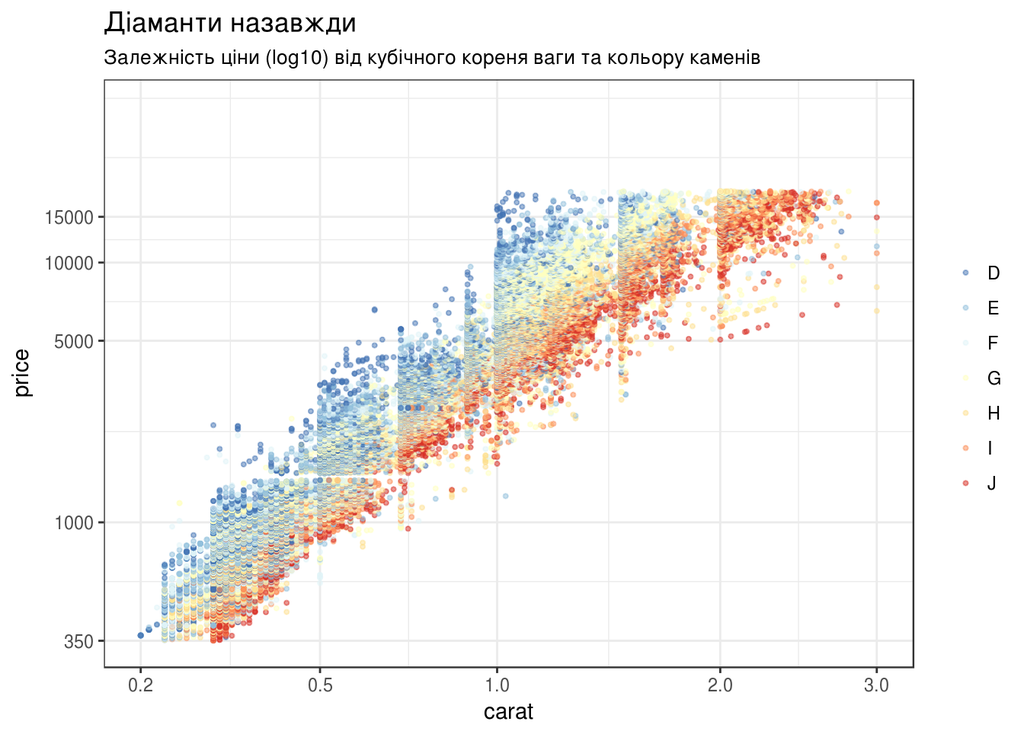

```r
p <- diamonds %>%
    ggplot(  aes(carat, price, colour=color)) +
    geom_point(alpha = 0.5, size = .75) +
    scale_colour_brewer(type = 'div', palette = 7, direction = -1,
        guide = guide_legend(title = NULL, reverse=F)) +
    scale_x_continuous(trans=cubroot_trans(), limits = c(0.2,3),
        breaks = c(0.2, 0.5, 1, 2, 3)) +
    scale_y_continuous(trans=log10_trans(), limits = c(350,40000),
        breaks = c(350, 1000, 5000, 10000, 15000)) +
    theme_bw() + theme(legend.key = element_blank()) +
    labs(title = "Діаманти назавжди", subtitle = 'Залежність ціни (log10) від кубічного кореня ваги та кольору каменів')
  #ggtitle('Price (log10) by Cubed-Root of Carat and Color')
p
```

Бачимо, що від кольору(насправді це жовтизна - чим вона більше, тим менше вартість) ціна залежить не так сильно, як від чистоти каменю. Лише на великих розмірах - після одного карату, цей фактор починає суттєво впливати на ціну.

Мінімальна версія попереднього графіка (якщо викинути масштабування, заголовки тощо) Можна добре побачити, якою анатомія графіка в ggplot

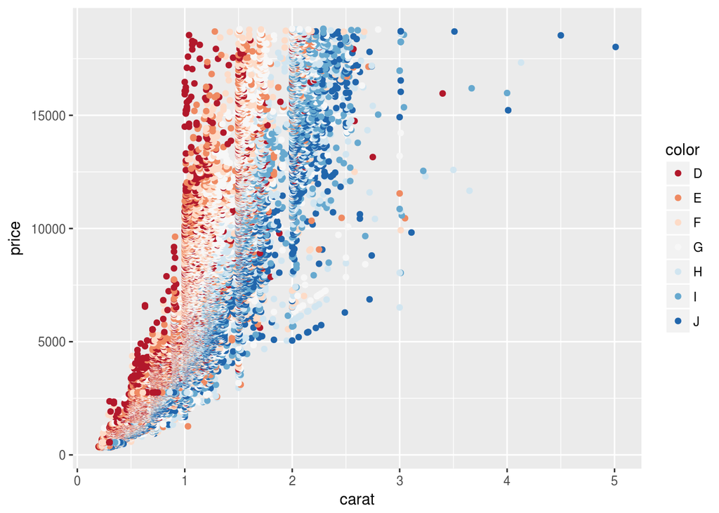

```r
diamonds %>% # 1. спочатку дані
    # 2. потім "естетика", тобто
    # у який спосіб ми показуємо кожну цікаву змінну. На цей раз
    # вагу в каратах показуємо по вісі X,
    # ціну - по вісі Y,
    # color діамантів - ( color, from J (worst) to D (best)) це насправді, наскільки він
    # прозорий - показуємо, правильно, кольором
    ggplot(  aes(x = carat, y = price, colour=color)) +
    # 3. нарешті задаємо геометрію (яким буде тип графіка?). цей - точковий, або діаграма розсіяння
    geom_point() +
    # 4. шкала (для кольору )
    scale_colour_brewer(type = 'div', palette = 5)
```

Плюч цього варіанта - всього лише три строчки коду. Мінус - без трансформацій X та Y робити аналіз не так зручно.

:tada: :tada: :tada:

Чого не вистачає? динаміки цін - залишається для домашньої роботи

Ідея та приклади позичені з блога Solomon Messing